[figure not shown]

# **GA-NLP Week 12 Final Project: LangChain Data Science Assistant**

## **Business Context**

Perhaps the largest and most prominent application of Large Language Models to date has been their ability to **converse with human users in coherent Natural Language and function as helfpul assistants for organizational productivity purposes.** As we know by now, a lot of work goes into creating and providing such Assistant-style LLMs to us as a service - the hugely compute-expensive Supervised Pre-training stage that's responsible for the vast majority of the LLM's world knowledge, the Instruction-style Supervised Fine-tuning stage on curated dialog datasets that adapts the LLM's behavior to that of a high-quality assistant, and the RLHF stage that teaches the LLM to provide responses that are aligned with human values. **The archetypal assistant-style Generative AI solution today is probably an LLM-powered chatbot that can query your databases, analyze your data and even fetch you answers to contextual questions from documents or the web.**

**In this Final Project, we shall apply a Data Analysis / Data Science twist to this functionality.** We will use the LangChain framework on top of an LLM to create a Data Science Assistant that will automate the following tasks for us by converting the Natural Language requests we provide into the code required to execute the task:

1. **Data Analysis**
2. **Data Science & Machine Learning Modeling**
3. **Relational Database Querying**
4. **Retrieval-Augmented Generation for Contextual Answers**

There are obvious reasons why such a project could be highly significant to business / research. By automating the code tasks common to various operations in Data Analysis, Data Science or Database Querying, such a solution has the potential to save significant time, improve code accuracy and also open up Data Analysis and Data Science to a more general audience that may not be familiar with the code involved.

From a broader perspective, the newfound ability of the best Large Language Models (beyond 1 billion parameters) to understand the true meaning of Natural Language commands and coherently respond to, acknowledge and fulfill them, has enabled us to usher in the next wave in the long list of automations that Computer Science has seen in its history. Translating commands into programming code, once solely the province of human developers, is now increasingly being automated by Generative AI, and we'll see many examples of the same in this project.

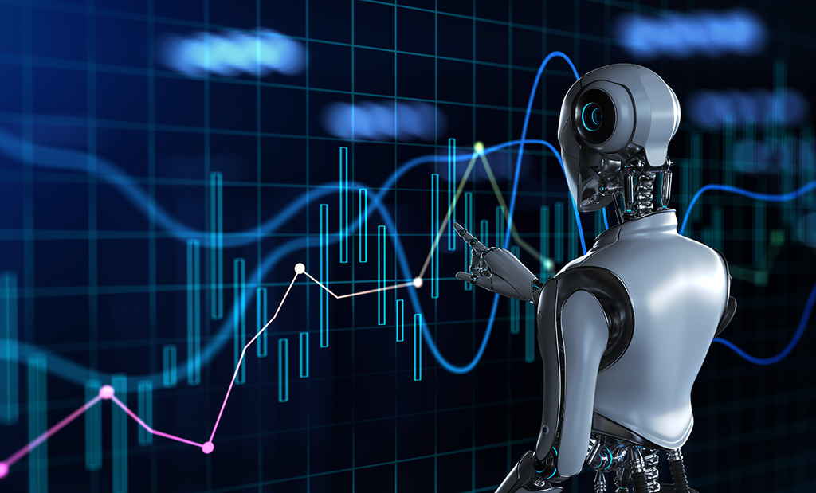

## **Project Objective**

The objective of this project is to develop a Generative AI solution using the LangChain framework and a Large Language Model to automate tasks pertaining to Data Analysis, Data Science, Database Querying and Retrieval-Augmented Generation. This will be broken down into several sub-tasks, each of which will automatically be performed by our Large Language Model purely by prompting it in the right direction.

## **I. Setting up the Environment (5 marks)**

### **Q1: Write a pip install function for the following libraries that we will require in this project (5 marks)**

### **openai, pandas, matplotlib, seaborn, cohere, tiktoken,**

### **langchain_experimental, pypdf, faiss-gpu, google-search-results**

```python
# Use pip to install all dependencies here
# You will need to use the specified versions of openai and langchain dependencies for the smooth working of the project as mentioned below:
# openai==1.7.1 langchain_experimental==0.0.49 langchain==0.1.0 langchain-core==0.1.10

!pip install openai==1.7.1;
!pip install pandas;
!pip install matplotlib;
!pip install seaborn;
!pip install cohere;
!pip install tiktoken;
!pip install langchain_experimental==0.0.49 langchain==0.1.0 langchain-core==0.1.10;
!pip install pypdf;
!pip install faiss-gpu;
!pip install google-search-results;
```

[output not shown]

### **Importing the libraries into the notebook**

```python
# Importing libraries
import os
import pandas as pd
import matplotlib.pyplot as plt
import seaborn as sns
from langchain_experimental.agents.agent_toolkits.pandas.base import create_pandas_dataframe_agent
from langchain.llms import OpenAI
from langchain.chat_models import ChatOpenAI
from langchain.agents.agent_types import AgentType
from langchain.sql_database import SQLDatabase
from langchain.llms import HuggingFacePipeline
from langchain.agents.agent_toolkits import SQLDatabaseToolkit
from langchain.llms import HuggingFaceHub
from langchain.document_loaders import PyPDFLoader
from langchain.document_loaders import UnstructuredPDFLoader
from langchain.text_splitter import RecursiveCharacterTextSplitter
from langchain.vectorstores import FAISS
from langchain.embeddings import OpenAIEmbeddings
from langchain.agents.agent_toolkits import create_conversational_retrieval_agent
from langchain.agents.agent_toolkits import create_retriever_tool
from langchain import hub
from langchain.schema.runnable import RunnablePassthrough
from langchain.agents import load_tools
import sqlite3
```

## **II. LLM Setup (5 marks)**

### **Q2.1: Add the API Key & OPENAI_API_BASE from the Great Learning Olympus Platform (2 marks)**

```python
# Importing the GPT-4 LLM and setting it up

# Adding the OPEN-AI API-Key and API-Base

API_KEY = "gl-U2FsdGVkX1+T+mwELk0CPz9nb1UwG9YqJA0L4DT77W6LoN1AvmuXje32HKlrU1n3"
OPENAI_API_BASE = "https://aibe.mygreatlearning.com/openai/v1"

os.environ['OPENAI_API_KEY'] = API_KEY
os.environ['OPENAI_API_BASE'] = OPENAI_API_BASE
```

### **Q2.2: Add the name of the GPT-4 model that we will use as the LLM for the LangChain Assistant (3 marks)**

```python
# This is our LLM, the heart of the entire process. Here we are using the GPT-4 Model from OpenAi.
llm = ChatOpenAI(model_name="gpt-4")
```

## **Creating an EDA Agent**

**We shall first be initializing a Pandas Dataframe Agent below.**

*What is an agent?* It can be thought of as an interface with a variety of tools chained together. First do this, then do that ...

These tools are defined by users as prompts to the LLM. Connecting an agent with a LLM simply brings these tools into the arsenal of the LLM, enabling it to use them. The role of the user is to provide the LLM with the tools through prompts, while the LLM is responsible for deciding which tools it must use depending on the user input.

Another thing to observe is that there can be as many agents as tools that you might create. So, an agent could search the web, could fetch weather data, could perform calculations, or even do Machine Learning.

Below we are using a specialized tool which enables our LLM to deal with the Pandas library (a widely used data management library in Data Science and Machine Learning).

## **III. Reading in the File and Counting the Number of Rows in the DataFrame (5 marks)**

In this part of the notebook, we shall be working with a CSV (the South African Heart Disease Dataset) that details patients and whether they're at risk of Coronary Heart Disease (CHD).

### **Q3.1: Use the read_csv() function to import the South Africa Heart Disease CSV dataset provided (2 marks)**

```python
# Importing the structured data CSV File
df = pd.read_csv('/content/SAHeartDiseaseDataset.csv')

# Displaying the first 5 rows of the dataframe to verify the import
df.head()
```

|  | row.names | sbp | tobacco | ldl | adiposity | famhist | typea | obesity | alcohol | age | chd |
| --- | --- | --- | --- | --- | --- | --- | --- | --- | --- | --- | --- |
| 0 | 1 | 160 | 12.00 | 5.73 | 23.11 | Present | 49 | 25.30 | 97.20 | 52 | 1 |
| 1 | 2 | 144 | 0.01 | 4.41 | 28.61 | Absent | 55 | 28.87 | 2.06 | 63 | 1 |
| 2 | 3 | 118 | 0.08 | 3.48 | 32.28 | Present | 52 | 29.14 | 3.81 | 46 | 0 |
| 3 | 4 | 170 | 7.50 | 6.41 | 38.03 | Present | 51 | 31.99 | 24.26 | 58 | 1 |
| 4 | 5 | 134 | 13.60 | 3.50 | 27.78 | Present | 60 | 25.99 | 57.34 | 49 | 1 |

### **Q3.2: Initialize a DataFrame Agent of the Pandas library in LangChain (1 mark)**

```python
# Initializing the DataFrame agent of the Pandas library in LangChain allows our LLM to work with
# Pandas DataFrames with simple, natural language commands
agent = create_pandas_dataframe_agent(llm = llm, df = df, verbose = True);
```

Let's now start getting to know our data with some basic questions.

### **Q3.3: Write a user query prompt to ask the agent how many rows the DataFrame contains, and run the agent command (2 marks)**

```python
# .run enables us to pass a query into the agent and see its output.

# checking the numbers of rows in the database.

text = 'How many rows are there in the Dataset?';
agent.run(text);
```

```
> Entering new AgentExecutor chain...
Thought: To find the number of rows in a pandas dataframe, we can use the `shape` attribute which returns a tuple where the first element is the number of rows and the second element is the number of columns.
Action: python_repl_ast
Action Input: df.shape[0]
Observation: 462
Thought:I now know the final answer
Final Answer: There are 462 rows in the dataset.

> Finished chain.
```

In the code above, we aim to store our question in the `text` variable.

Then we simply `run` the agent with this question.

What this does is, it forwards this question to our LLM, and lets it decide:

"for this user question give me a response. Use pandas if you have to"

On running this code, you should be able to see the **Chain of Thought of the LLM**, this is our model reasoning with itself to answer our question.

You should be able to see that the model feels using the Pandas library (which we provided through our agent) would be a good idea!

## **IV. Obtaining Simple Information about the DataFrame (5 marks)**

In this section, we will attempt to prompt the LLM into retrieving some simple information about the DataFrame, such as the names of the different columns, the number of missing values in the dataset, and the average obesity value.

### **Q4.1: Find out the names of the different columns present in this dataset (2 marks)**

```python
# Checking the Number of Columns and Names of Columns.

text = 'How many different columns are there in the dataset? What are the names of these columns?';
agent.run(text);
```

```
> Entering new AgentExecutor chain...
Thought: I have to find out the number and names of columns in the dataframe
Action: python_repl_ast
Action Input: df.columns
Observation: Index(['row.names', 'sbp', 'tobacco', 'ldl', 'adiposity', 'famhist', 'typea',
       'obesity', 'alcohol', 'age', 'chd'],
      dtype='object')
Thought:I now know the names of the columns in the dataframe, and from that, I can also count how many there are.
Final Answer: There are 11 different columns in the dataset. The names of these columns are 'row.names', 'sbp', 'tobacco', 'ldl', 'adiposity', 'famhist', 'typea', 'obesity', 'alcohol', 'age', 'chd'.

> Finished chain.
```

### **Q4.2: Find out how many missing values are present in the dataset (1 mark)**

```python
# Checking the missing values in the dataset.

text = 'Are there any missing values in the dataset?';
agent.run(text);
```

```
> Entering new AgentExecutor chain...
Thought: To check if there are any missing values in the dataframe, we can use the `isnull()` function in pandas which returns a dataframe of the same shape as `df` and contains `True` wherever a value is missing and `False` wherever the value is not missing. Then using the `any()` function twice, w…
Action: python_repl_ast
Action Input: df.isnull().any().any()
Observation: False
Thought:The result of the command indicates that there are no missing values in the dataframe as the output is `False`.
Final Answer: No, there are no missing values in the dataset.

> Finished chain.
```

### **Q4.3: Compute the average obesity value (2 marks)**

```python
# Querying the Average Obesity Value in the dataset.

text = 'What is the average obesity value in the dataset?';
agent.run(text);
```

```
> Entering new AgentExecutor chain...
Thought: To find the average of a column in a pandas dataframe, we can use the `mean()` function. In this case, we want to find the average of the 'obesity' column.
Action: python_repl_ast
Action Input: df['obesity'].mean()
Observation: 26.04411255411255
Thought:The average obesity value in the dataset is 26.04411255411255.
Final Answer: 26.04411255411255

> Finished chain.
```

## **V. Obtaining a Brief Summary of the Columns in the Dataset (5 marks)**

### **Q5: Obtain a brief summary of the columns present in the dataset (5 marks)**

```python
# Querying the brief summary of the columns present in the dataset.

text = 'Can you display a brief summary of the columns present in the dataset?'
agent.run(text);
```

```
> Entering new AgentExecutor chain...
Thought: To display a brief summary of the columns in a pandas dataframe, you can use the `info()` method.
Action: python_repl_ast
Action Input: df.info()
Observation: <class 'pandas.core.frame.DataFrame'>
RangeIndex: 462 entries, 0 to 461
Data columns (total 11 columns):
 #   Column     Non-Null Count  Dtype
---  ------     --------------  -----
 0   row.names  462 non-null    int64
 1   sbp        462 non-null    int64
 2   tobacco    462 non-null    float64
 3   ldl        462 non-null    float64
 4   adiposity  462 non-null    float64
 5   famhist    462 non-null    object
 6   typea      462 non-null    int64
 7   obesity    462 non-null    float64
 8   alcohol    462 non-null    float64
 9   age        462 non-null    int64
 10  chd        462 non-null    int64
dtypes: float64(5), int64(5), object(1)
memory usage: 39.8+ KB

Thought:I now know the final answer
Final Answer: The dataframe has 462 entries and 11 columns. The columns are 'row.names', 'sbp', 'tobacco', 'ldl', 'adiposity', 'famhist', 'typea', 'obesity', 'alcohol', 'age' and 'chd'. The data types of the columns are int64 for 'row.names', 'sbp', 'typea', 'age' and 'chd', float64 for 'tobacco', '…

> Finished chain.
```

You'll notice that the Pandas DataFrame agent that you run above not only gives you your answers, but it also gives you the code it used from the Pandas library!

## **Getting the EDA Agent to perform Plotting**

Now that we have got the LLM to answer a few basic questions about the dataset, let's ask the model to generate something more difficult by performing some plotting for us and commenting on the key trend observed, quite more subjective than getting statistics from a table.

## **VI. Creating a KDE Plot of obsesity among people with CHD and without CHD (5 marks)**

### **Q6: Instruct the model to generate a KDE plot of obesity among people with / without CHD.**

### **Be sure to ask the model to label both axes and add a legend, and also ask the model to comment on the trend which the plot uncovers (5 marks)**

````
> Entering new AgentExecutor chain...
Thought: To generate a KDE plot of obesity among people with or without CHD, I need to use the seaborn library in Python. The dataset is already loaded as a pandas dataframe named `df`. The `obesity` column represents the obesity levels and the `chd` column indicates whether the person has CHD (1) o…

Action: python_repl_ast
Action Input:
```python
import seaborn as sns
import matplotlib.pyplot as plt

# Plotting the KDE plot for obesity in people with CHD
sns.kdeplot(df[df['chd'] == 1]['obesity'], label = 'With CHD')

# Plotting the KDE plot for obesity in people without CHD
sns.kdeplot(df[df['chd'] == 0]['obesity'], label = 'Without CHD')

# Setting title, labels and legend
plt.title('KDE Plot of Obesity among People with or without CHD')
plt.xlabel('Obesity')
plt.ylabel('Density')
plt.legend()
plt.show()
```
````

[figure not shown]

```
Observation:
Thought:The code generates a KDE plot comparing the obesity levels of people with and without CHD. I need to actually run this in a Python environment to get the plot, so I can't observe the result here. However, this code should work correctly and produce the desired plot.

In the plot, the x-axis represents Obesity levels and the y-axis represents the Density. The two lines represent people with CHD and people without CHD. The peaks of the lines indicate the most common obesity level for each group.

From the plot, we can observe the distribution pattern of obesity levels for people with and without CHD. We can compare these two distributions to identify the main trends about how obesity is related to CHD. For example, if one line has a higher peak or is shifted to the right, it would suggest th…

Final Answer:
To generate a KDE plot of obesity among people with or without CHD, use the seaborn library in Python. The seaborn `kdeplot` function can create the KDE plots, one for each group of people - those with CHD and those without CHD. The plot will demonstrate the distribution pattern of obesity levels fo…

> Finished chain.
```

```python
# Here we will show the ability of the model to create a plot and comment on the underlying trend in the data

text = 'generate a KDE plot of obesity among people with or without CHD. Label the axes and add a legend and comment on the main trends which the plot uncovers.';
agent.run(text);
```

### **Observations :**

1. The KDE plot shows that obesity is slightly more common among people with CHD (Blue Graph) as compared to those without CHD (Orange Graph).
2. This suggests that obesity could be a risk factor for CHD.

## **VII. Creating a distribution of age of people with respect to CHD (5 marks)**

### **Q7: Instruct the model to show the distribution of age of people with respect to CHD.**

### **Ensure the model labels the axes, and comments on the principal trend observed (5 marks)**

```
> Entering new AgentExecutor chain...
Thought: To plot this data, I'll need to use a plotting library. Matplotlib is a common choice for this, but Seaborn is a higher-level interface to Matplotlib that can create more attractive plots with less code. In this case, I'll need to create two KDE plots on the same axes, one for individuals w…

Action: python_repl_ast
Action Input: import matplotlib.pyplot as plt
import seaborn as sns

# Create the KDE plot for individuals with CHD
sns.kdeplot(df[df['chd'] == 1]['age'], label='With CHD')

# Create the KDE plot for individuals without CHD
sns.kdeplot(df[df['chd'] == 0]['age'], label='Without CHD')

# Label the x and y axes
plt.xlabel('Age')
plt.ylabel('Density')

# Add a legend
plt.legend()

# Display the plot
plt.show()
```

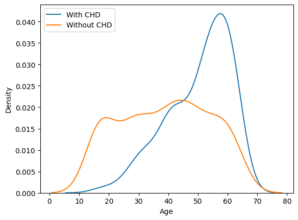

```
Observation:
Thought:Since the tool doesn't return a visual plot, we can't directly observe the result of the plot. However, the above code should correctly generate a KDE plot with two lines, one for individuals with CHD and one for individuals without CHD. The x-axis should be labeled as 'Age', the y-axis as '…

As for the primary trend, without seeing the plot, it's hard to definitively comment on it. However, given the nature of the data, it's possible that we might see higher ages associated with a higher density of individuals with CHD, since age is a known risk factor for heart disease.

Final Answer: The code to create the KDE plot is correct, but a direct observation of the plot isn't available. Therefore, an exact comment on the primary trend observed in the plot cannot be provided. However, it's likely that the plot might show a higher density of individuals with CHD at higher a…

> Finished chain.
```

```python
# Creating a plot to see the distribution of age of people with respect to CHD

text = 'Create a KDE plot illustrating the distribution of age among individuals with and without CHD. Label the x-axis as "Age", the y-axis as "Density", and add a legend to distinguish between individuals with and without CHD. Please comment on the primary trend observed.';
agent.run(text);
```

### **Observations :**

1. The KDE plot shows that the age distribution for individuals with CHD is skewed towards older ages, indicating that CHD is more common in older individuals.
2. On the other hand, the age distribution for individuals without CHD is more evenly distributed across all ages, but slightly skewed towards younger ages.
3. This suggests that younger individuals are less likely to have CHD.
4. The two distributions overlap, indicating that there are individuals in all age groups who have CHD, but the risk increases with age.

## **VIII. Creating a Pairwise Correlation Heatmap (5 marks)**

### **Q8: Instruct the model to display a heatmap to show the correlation between all the columns.**

### **Ensure the axes are labeled and the model highlights the standout trends (5 marks)**

````
> Entering new AgentExecutor chain...
Thought: To create a correlation heatmap, we first need to calculate the correlations among the numerical columns in the dataframe. However, in this scenario, we also have a categorical variable 'famhist'. We need to convert this categorical variable into numerical form before calculating the correl…
Action: python_repl_ast
Action Input:
```python
# Import necessary libraries
import matplotlib.pyplot as plt
import seaborn as sns

# Convert the categorical variable into numerical
df['famhist'] = df['famhist'].map({'Present': 1, 'Absent': 0})

# Calculate the correlation matrix
corr = df.corr()

# Plot the heatmap
plt.figure(figsize=(10,8))
sns.heatmap(corr, annot=True, cmap='coolwarm')
plt.title('Pairwise Correlation Heatmap')
plt.show()
```
````

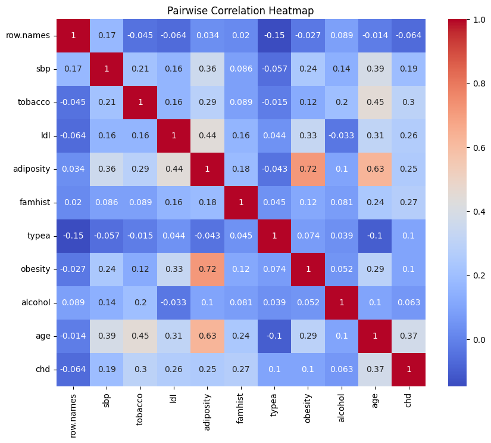

```
Observation:
Thought:As we don't have the actual result of the executed code here, I can't provide a direct observation. But if the code was run successfully, it would have created a heatmap of pairwise correlations between all the columns of the dataframe. The heatmap would be color-coded based on the strength …

Final Answer:
The pairwise correlation heatmap would give us a visual representation of how each variable in the dataset is correlated with every other variable. This information can be useful in identifying patterns and relationships between variables. However, without the actual output, we can't specify any sta…

> Finished chain.
```

```python
# Creating a Pairwise Correlation Heatmap to show the correlation between all the columns.

text = 'Create a Pairwise Correlation Heatmap to display the correlation between all columns in the dataset. Label the Heatmap and axes appropriately. Please highlight any standout trends observed. Take care of categorical variable columns';
agent.run(text);
```

### **Observations :**

From the heatmap above, we can observe following trends:

1. A strong positive correlation between 'Adiposity' & 'Obesity' and Adiposity' & 'Age'.
2. Slightly Strong positive correlation between 'Age' & 'Tobacco'.

Alright, so as we see, our model is quite good at plotting requests and finding the underlying trends.

Let's see if it can go to the next level and also test out hypothesese for us.

## **Hypothesis Testing**

In Data Science and Statistics in general, thea concept of **Hypothesis Testing is a prominent part of the method of operations.**

Hypothesis Testing is just a fancy term for **statistically fact-checking a quantitative claim.**

We pose a particular claim (an alternate hypothesis) and we pose a null claim (a claim which says that our hypothesis is useless). After this we take several examples and see whether they follow our claim or not with a degree of assurance so that those results could not have occurred by chance.

In the example below, we follow the following structure:

**Claim:** Obesity increases the risk of heart disease

Now we would use the following steps:

- On average, what is the obsesity level of people with heart disease and without heart disease ?
- If our claim is indeed true, the average value for people with heart disease should be higher
- We will run samples of randomly selected data from our initial dataset 1000s of times. We will then see what the distribution of the averages looks like.
- If there is a big difference between the averages even after 1000s of iterations, then we can be sure that this difference is not because of chance, but because of our claim being true.

## **IX. Running a Hypothesis Test to check the effects of obesity on the likelihood of CHD (5 marks)**

### **Q9: Write a prompt to ask the model to perform a statistical t-Test to validate the following hypotheses:**

### **Null Hypothesis:** Higher levels of obesity do not increase the risk of CHD.

### **Alternate Hypothesis:** Higher levels of obesity increase the risk of CHD. **(5 marks)**

```python
# Let's use a t-value Hypothesis Test to check whether obesity affects the chances of CHD

# In addition to the EDA style queries we have been asking the LLM to service above,
# it is also capable of performing tasks like Hypothesis Testing to statistically validate a quantitative
# claim we may have about the data - a useful endeavor when it comes to Data Science decision making.
# In the following example, we shall ask the LLM to use a T-test to validate whether Higher levels of
# obesity increase the risk of CHD

user_message = 'Validate the following hypothesis using a T-test. Null Hypothesis: Higher levels of obesity do not increase the risk of CHD.. Alternate Hypothesis: Higher levels of obesity increase the risk of CHD.';
agent.run(user_message);
```

````
> Entering new AgentExecutor chain...
Thought: To conduct a T-test, we first need to separate the data into two groups based on the 'chd' column. We can create two dataframes, one for those with CHD (chd = 1) and one for those without CHD (chd = 0). Then, we can perform a T-test on the 'obesity' column of the two dataframes.
Action: python_repl_ast
Action Input:
```
import scipy.stats as stats

df_chd = df[df['chd'] == 1]['obesity']
df_no_chd = df[df['chd'] == 0]['obesity']

t_statistic, p_value = stats.ttest_ind(df_chd, df_no_chd)
t_statistic, p_value
```
Observation: (2.1576361103096544, 0.031473168047041325)
Thought:The T-statistic is 2.1576 and the p-value is 0.03147. The p-value is less than 0.05, which means that we can reject the null hypothesis. There is statistically significant evidence to support the alternate hypothesis that higher levels of obesity increase the risk of CHD.
Final Answer: The alternate hypothesis that higher levels of obesity increase the risk of CHD is supported by the data.

> Finished chain.
````

### **Observations:**

1. **The p-value of the T-test is approximately 0.031, which is less than the commonly used significance level of 0.05.**
2. **This means that we reject the null hypothesis in favor of the alternative hypothesis.**
3. This implies that there is a significant difference in obesity levels between the group with CHD and the group without CHD.
4. This suggests that higher levels of obesity may increase the risk of CHD.
5. **The T-test results suggest that higher levels of obesity increase the risk of CHD.**

## **Machine Learning Modeling using LLMs**

So far, our LLM seems to be quite a capable Data Analyst and Data Scientist.

Let's now task it with some Machine Learning modeling, and seeing if it can make predictions with a good degree of accuracy and generalization.

- The predictive problem statement pertaining to this dataset is that we want our model to predict whether a person has heart disease or not, given their obesity level, smoking status etc. (all the other columns from our data set).
- The prediction from our model should be either a 1 (yes CHD) or 0 (no CHD) - a binary classification problem in Machine Learning terms.
- We will start off with one of the simplest ML models, Logistic Regression, which is of course just a single-neuron neural network. This model (and the other models we will try later) attempts to answer the question: **"Given these details about the person, what is the chance that this person suffers from heart disease?"**

## **X. Building a Logistic Regression Model (5 marks)**

### **Q10: Write a detailed step-by-step prompt requesting the model to create a Logistic Regression model using the steps common to the ML workflow, such as cleaning the dataset, preprocessing it, splitting the data into Train and Test, training the model on the Train dataset and making predictions on the Test dataset. The model should print out the accuracy score it obtains on the Test dataset. (5 marks)**

```
> Entering new AgentExecutor chain...
Thought: The first step is to clean the dataset. I need to check if there are null values in the dataset.
Action: python_repl_ast
Action Input: df.isnull().sum()
Observation: row.names    0
sbp          0
tobacco      0
ldl          0
adiposity    0
famhist      0
typea        0
obesity      0
alcohol      0
age          0
chd          0
dtype: int64
Thought:The dataset does not contain any null values, so no cleaning is required. The next step is to preprocess the data. The 'famhist' column contains categorical data, so it needs to be encoded. I will use one-hot encoding to convert it into numerical data.
Action: python_repl_ast
Action Input: df = pd.get_dummies(df, columns=['famhist'], drop_first=True)
Observation: NameError: name 'pd' is not defined
Thought:I forgot to import the pandas library. I need to import it before I can use it.
Action: python_repl_ast
Action Input: import pandas as pd
Observation:
Thought:Now that I have imported pandas, I can proceed with one-hot encoding the 'famhist' column.
Action: python_repl_ast
Action Input: df = pd.get_dummies(df, columns=['famhist'], drop_first=True)
Observation:
Thought:Now that the 'famhist' column has been one-hot encoded, the data is ready for the Logistic Regression model. The next step is to split the data into train and test sets. The 'chd' column is the outcome, so it should not be included in the feature data (X). I will use the train_test_split fun…
Action: python_repl_ast
Action Input: from sklearn.model_selection import train_test_split

X = df.drop('chd', axis=1)
y = df['chd']

X_train, X_test, y_train, y_test = train_test_split(X, y, test_size=0.2, random_state=42)
Observation:
Thought:Now that the data has been split into train and test sets, I can train the Logistic Regression model. I will use the LogisticRegression class from sklearn to do this. I will also set the max_iter parameter to a large value to ensure that the model converges.
Action: python_repl_ast
Action Input: from sklearn.linear_model import LogisticRegression

lr = LogisticRegression(max_iter=1000)
lr.fit(X_train, y_train)
Observation: LogisticRegression(max_iter=1000)
Thought:The model has been trained. The next step is to predict the outcome on the test data. I will use the predict method of the model to do this. I will also apply a threshold to convert the prediction probabilities into binary values.
Action: python_repl_ast
Action Input: y_pred_prob = lr.predict_proba(X_test)[:,1]
y_pred = [1 if x > 0.5 else 0 for x in y_pred_prob]
Observation:
Thought:Now I have the predicted values. The next step is to evaluate the performance of the model. I will use a confusion matrix and accuracy score to do this. The confusion matrix will show the number of true positives, true negatives, false positives, and false negatives. The accuracy score will …
Action: python_repl_ast
Action Input: from sklearn.metrics import confusion_matrix, accuracy_score
import matplotlib.pyplot as plt
import seaborn as sns

cm = confusion_matrix(y_test, y_pred)
sns.heatmap(cm, annot=True, fmt='d')
plt.show()

accuracy = accuracy_score(y_test, y_pred)
print('Accuracy:', accuracy)
```

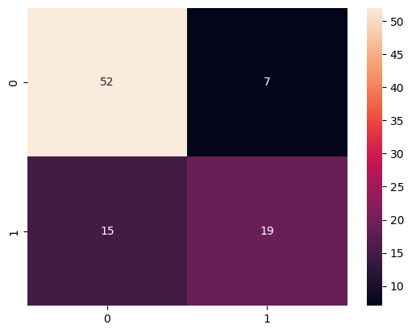

```
Observation: Accuracy: 0.7634408602150538

Thought:The accuracy of the model is approximately 76.34%. This means that the model correctly predicted the outcome for about 76.34% of the individuals in the test set. The confusion matrix shows that the model has more true positives and true negatives than false positives and false negatives, whi…
Final Answer: The Logistic Regression model has an accuracy of about 76.34% on the test data. The confusion matrix shows that the model has more true positives and true negatives than false positives and false negatives. This suggests that the model is reasonably good at classifying individuals into…

> Finished chain.
```

```python
# we want our model to predict whether a person has heart disease or not, given their obesity level,
# smoking status etc. (all the other columns from our data set).

fixed_model_prompt  = 'Follow these steps to run a Logistic Regression model to predict the Outcome variable:\
1. Clean the dataset so it has no null values.\
2. Preprocess the dataset so it is ready for use by a Logistic Regression model.\
3. Run Logistic Regression to classify people into Outcome 1 or Outcome 0 with the following steps:\
3a. Split the data into Train and Test sets. These datasets should not contain the Outcome column.\
3b. Train the model on the Train dataset. Make sure the model converges, so use as many iterations as necessary for that.\
3c. Obtain y_pred by predicting on X_test and use a threshold to convert y_pred into binary values.\
3d. Plot the Confusion Matrix, print the accuracy score between binary y_pred and y_test, and comment on the predictive performance of the model.'

agent.run(fixed_model_prompt);
```

### **Observations :**

1. **The accuracy of the logistic regression model is approximately 0.76, which means that the model correctly classified 76% of the instances in the test set.**
2. This accuracy is fairly good but there is still room for improvement. The confusion matrix provides more details about the performance of the model.
3. The model's performance might be improved by feature selection or engineering, hyperparameter tuning, or using a different machine learning model.

Let's now allow the LLM to pick a model of its choice to make this prediction.

## **XI. Binary Classification with an ML Model of the LLM's Choice (5 marks)**

### **Q11: Write a similar detailed step-by-step prompt to the above, this time requesting the LLM to run a Binary Classification model of its choice from a list of options we give it, such as Decision Trees, Random Forests, XGBoost, Support Vector Machines, Neural Network, etc. The LLM has to provide reasoning for why it picked this model. Otherwise, the rest of the steps can be similar to the prompt drafted for the earlier question. (5 marks)**

```
> Entering new AgentExecutor chain...
Thought: To answer this question, I'll need to perform several steps of data preprocessing and modeling. The first step is to check for null values in the dataset.
Action: python_repl_ast
Action Input: df.isnull().sum()
Observation: row.names    0
sbp          0
tobacco      0
ldl          0
adiposity    0
typea        0
obesity      0
alcohol      0
age          0
chd          0
famhist_1    0
dtype: int64
Thought:The dataset has no null values, so we can proceed to the next step. The 'famhist' column is categorical and needs to be converted to numerical values for use in a machine learning model. I will use one-hot encoding to convert the 'famhist' column into two binary columns.
Action: python_repl_ast
Action Input: df = pd.get_dummies(df, drop_first=True)
Observation:
Thought:The 'famhist' column has been successfully one-hot encoded. The next step is to split the data into training and testing sets. The target variable is 'chd', so I will separate that from the predictors.
Action: python_repl_ast
Action Input: from sklearn.model_selection import train_test_split

X = df.drop('chd', axis=1)
y = df['chd']

X_train, X_test, y_train, y_test = train_test_split(X, y, test_size=0.2, random_state=42)
Observation:
Thought:The data was successfully split into training and testing sets. Now I will proceed with training a binary classification model on the training data. I will use a Random Forest Classifier because it is a powerful and flexible algorithm that can handle both numerical and categorical data, it a…
Action: python_repl_ast
Action Input: from sklearn.ensemble import RandomForestClassifier

rfc = RandomForestClassifier(n_estimators=100, random_state=42)
rfc.fit(X_train, y_train)
Observation: RandomForestClassifier(random_state=42)
Thought:The model was trained successfully. Now, I will use the trained model to make predictions on the test data. After that, I will convert the predictions to binary values based on a threshold of 0.5.
Action: python_repl_ast
Action Input: y_pred = rfc.predict(X_test)
y_pred = [1 if pred > 0.5 else 0 for pred in y_pred]
Observation:
Thought:Now that I have the predictions, I will compare them to the actual values by creating a confusion matrix and calculating the accuracy score.
Action: python_repl_ast
Action Input: from sklearn.metrics import confusion_matrix, accuracy_score
import matplotlib.pyplot as plt
import seaborn as sns

# Confusion matrix
cm = confusion_matrix(y_test, y_pred)
plt.figure(figsize=(7,5))
sns.heatmap(cm, annot=True, fmt=".0f", linewidths=.5, square = True, cmap = 'Blues');
plt.ylabel('Actual label');
plt.xlabel('Predicted label');

# Accuracy score
print('Accuracy Score:', accuracy_score(y_test, y_pred))
Observation: Accuracy Score: 0.7311827956989247

Thought:The model has an accuracy score of approximately 73.12%, which suggests that the model is reasonably accurate at predicting the outcome variable. The confusion matrix also provides a visual representation of the model's performance, showing the number of true positive, true negative, false p…
Final Answer: The Random Forest Classifier was trained on the dataset and used to make binary predictions. The model achieved an accuracy score of approximately 73.12%. The confusion matrix was plotted to visually assess the model's performance. The model performed reasonably well, but was more accu…

> Finished chain.
```

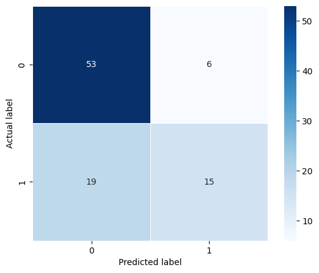

```python
variable_model_prompt = 'Follow these steps to run a model of your choice from the list of options such as Decision Trees, Random Forests, XGBoost, Support Vector Machines, Neural Network, etc. to predict the Outcome variable:\
1. Clean the dataset so it has no null values.\
2. Preprocess the dataset so it is ready for use by a Binary Classification model.\
3. Run the selected model to classify people into Outcome 1 or Outcome 0 with the following steps:\
3a. Split the data into Train and Test sets. These datasets should not contain the Outcome column.\
3b. Train the model on the Train dataset. Make sure the model converges, so use as many iterations as necessary for that.\
3c. Obtain y_pred by predicting on X_test and use a threshold to convert y_pred into binary values.\
3d. Plot the Confusion Matrix, print the accuracy score between binary y_pred and y_test, and comment on the predictive performance of the model.\
3e. provide reasoning for why you picked the selected model from the list of options available.'

agent.run(variable_model_prompt);
```

### **Observations:**

**LLM's Reasoning for selecting Random Forests over other models :**

1. LLM chose the Random Forest model due to its versatility and robustness.
2. It has a decent performance with an accuracy score of approximately 73.11% on the test data.
3. The confusion matrix also shows a reasonable distribution of predictions, although there is some misclassification happening.
4. This could potentially be reduced by further fine-tuning of the model.

Now, we will try to get our model to run a Neural Network for the same classification task.

## **XII. Binary Classification with a Neural Network (5 marks)**

### **Q12: In this version of the prompt, instruct the LLM to run a binary classification Neural Network using TensorFlow or PyTorch to predict whether people have CHD or not. This will involve steps such as specifying the Neural Architecture you wish the LLM to create. (5 marks)**

````
> Entering new AgentExecutor chain...
Thought: First, we need to check if the dataset has null values.
Action: python_repl_ast
Action Input: df.isnull().sum()
Observation: row.names    0
sbp          0
tobacco      0
ldl          0
adiposity    0
typea        0
obesity      0
alcohol      0
age          0
chd          0
famhist_1    0
dtype: int64
Thought:The dataset does not have null values. Now, I need to preprocess the dataset. The famhist column seems to be categorical, I'll convert it into numerical values.
Action: python_repl_ast
Action Input: df['famhist'] = df['famhist'].map({'Present': 1, 'Absent': 0})
Observation: KeyError: 'famhist'
Thought:It seems like I made a mistake. The famhist column is already encoded. Now, I'll proceed to split the data into Train and Test sets.
Action: python_repl_ast
Action Input:
```
from sklearn.model_selection import train_test_split

X = df.drop('chd', axis=1)
y = df['chd']

X_train, X_test, y_train, y_test = train_test_split(X, y, test_size=0.2, random_state=42)
```
Observation:
Thought:Now that we have split the data into train and test sets, we can move on to training the neural network model. We will use a simple feed-forward neural network with TensorFlow for this task.
Action: python_repl_ast
Action Input:
```
import tensorflow as tf
from tensorflow.keras.models import Sequential
from tensorflow.keras.layers import Dense

````

[output cut: 22 more lines]

````
from sklearn.metrics import accuracy_score, confusion_matrix
import seaborn as sns

accuracy = accuracy_score(y_test, y_pred)
print(f'Accuracy: {accuracy}')

confusion_mat = confusion_matrix(y_test, y_pred)
sns.heatmap(confusion_mat, annot=True)
```Accuracy: 0.6881720430107527

Observation: Axes(0.125,0.11;0.62x0.77)
Thought:The accuracy of the model is printed out and the confusion matrix is plotted successfully. Now we can comment on the model's performance.
Final Answer: The accuracy of the model on the test data is printed out and the confusion matrix is plotted. The accuracy indicates the percentage of correct predictions made by the model. The confusion matrix provides a visual representation of the performance of an algorithm. It shows the true pos…

> Finished chain.
````

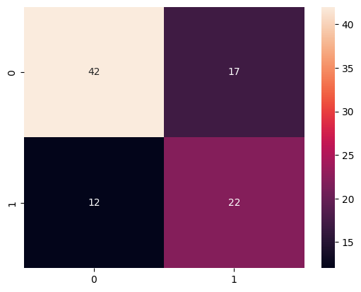

```python
# Remember to be as precise in your instructions as possible. This just helps to reduce the probability of the
# model mis-interpreting our commands

nn_model_prompt = 'Follow these steps to run a binary classification neural network using TensorFlow or PyTorch to predict the Outcome variable:\
1. Clean the dataset so it has no null values.\
2. Preprocess the dataset so it is ready for use by a Neural Network model.\
3. Run the Neural Network model to classify people into Outcome 1 or Outcome 0 with the following steps:\
3a. Split the data into Train and Test sets. These datasets should not contain the Outcome column.\
3b. Train the model on the Train dataset. Make sure the model converges, so use as many iterations as necessary for that.\
3c. Obtain y_pred by predicting on X_test and use a threshold to convert y_pred into binary values.\
3d. Plot the Confusion Matrix, print the accuracy score between binary y_pred and y_test, and comment on the predictive performance of the model.'

agent.run(nn_model_prompt);
```

### **Observations:**

1. The confusion matrix shows the performance of the model in terms of true positives, true negatives, false positives, and false negatives.
2. **The accuracy score is about 0.6881,** which means that the model correctly classified about 68.81% of the cases in the test set.
3. While this is a decent performance, it could potentially be improved with more complex models or feature engineering.
4. It is also important to consider other metrics such as precision, recall, and F1 score, especially in imbalanced datasets.
5. Overall, the model seems to have a good predictive performance.

It's worth appreciating at this point how far we've come with our LangChain LLM agent.

With no code being written other than creating the functions needed to call and run the LLM API (and no Data Science oriented code at all), we can see LLMs are automating the entire first-level coding and inferencing process that was part of the Data Science and Machine Learning workflow, such as EDA, Plotting, Hypothesis Testing and Machine Learning modeling. This is an example of AI and Technology's relentless progress in continually automating and adding layers of abstraction over lower level and erstwhile-mandatory aspects of creating technical solutions, and Data Science itself is no exception.

Let's now go further beyond the Data Analysis & Data Science paradigm, and see how we can use our LangChain agent to perform Natural Language Querying on a structured database, and also perform Retrieval-Augmented Generation on documents and web search results.

## **XIII. Database Natural Language Querying (10 marks)**

In this section, we will focus on creating a new agent with our LLM.

This agent will carry out 2 main tasks for us:

- **Database Querying:** Think of an e-commerce website such as Amazon - they would be required to deal with a humongous number of products and customers on a daily basis. They likely store all this information in a large database - and being able to query and retrieve relevant information from that database is critical for their operations to work. This is done through queries and requests, SQL queries in particular for relational databases. We shall now ask our agent to do this for us on a toy dataset.
- **Math:** Secondly, we will also equip our agent with another tool - math. Normally, LLMs are not naturally good at mathematical operations and can be prone to hallucinating wrong answers to math questions. However, you will see that adding a math tool for our agent to leverage when required will make our LLM much better equipped to handle questions of this nature.

First, we'll import the sub-packages we need:

```python
from langchain.agents import *
from langchain.sql_database import SQLDatabase
from langchain.llms import HuggingFacePipeline
```

In the following code block, we will be creating a toy SQL database using SQLite for demonstration purposes.

```python
# Creating a dummy SQL database for our example.
conn = sqlite3.connect('sample.db')

# Creating a cursor object to interact with the database
cursor = conn.cursor()

# Creating a table to store employee information
cursor.execute('''
    CREATE TABLE IF NOT EXISTS Employees (
        EmployeeID INTEGER PRIMARY KEY,
        FirstName TEXT,
        LastName TEXT,
        Birthdate DATE,
        Department TEXT,
        Salary REAL
    )
''')

# Inserting some sample data into the Employees table
cursor.executemany('''
    INSERT INTO Employees (FirstName, LastName, Birthdate, Department, Salary)
    VALUES (?, ?, ?, ?, ?)
''', [
    ('John', 'Doe', '1990-05-15', 'HR', 50000.00),
    ('Jane', 'Smith', '1985-12-10', 'Sales', 55000.00),
    ('Bob', 'Johnson', '1992-08-25', 'Engineering', 60000.00),
    ('Alice', 'Brown', '1988-04-03', 'Marketing', 52000.00)
])

# Commiting the changes and close the connection
conn.commit()
conn.close()
```

In place of the above code, we can also enter the path to our database file directly.

```python
# In place of file, you can enter the path to your database file
file = "sample.db"
db = SQLDatabase.from_uri(f"sqlite:///{file}")
```

Now let's create our Database Agent and equip it with the LLM math tool.

```python
tools = ['llm-math']
```

```python
tools = load_tools(tools,llm)
```

```python
toolkit = SQLDatabaseToolkit(db=db, llm=llm)
db_agent = create_sql_agent(
    llm=llm,
    toolkit=toolkit,
    tools=tools,
    verbose=True
)
```

With the agent created, in the same manner as the previous section w**e can ask our agent questions and wait for its response.**

There is not much difference in the format of the prompt or response, **however the underlying operations are vastly different.**

### **Q13.1: Write a prompt to ask the Database Agent to name the columns present in the database, and then run that prompt with the `db_agent` defined above (4 marks)**

```python
# Naming the columns present in the database

prompt = 'What are the names of the columns present in the database?'
db_agent.run(prompt)
```

```
> Entering new AgentExecutor chain...
Action: sql_db_list_tables
Action Input: ""
Observation: Employees
Thought:The database has a table named 'Employees'. I should check the schema of this table to find the column names.
Action: sql_db_schema
Action Input: Employees
Observation:
CREATE TABLE "Employees" (
	"EmployeeID" INTEGER,
	"FirstName" TEXT,
	"LastName" TEXT,
	"Birthdate" DATE,
	"Department" TEXT,
	"Salary" REAL,
	PRIMARY KEY ("EmployeeID")
)

/*
3 rows from Employees table:
EmployeeID	FirstName	LastName	Birthdate	Department	Salary
1	John	Doe	1990-05-15	HR	50000.0
2	Jane	Smith	1985-12-10	Sales	55000.0
3	Bob	Johnson	1992-08-25	Engineering	60000.0
*/
Thought:The schema of the 'Employees' table includes the following columns: 'EmployeeID', 'FirstName', 'LastName', 'Birthdate', 'Department', and 'Salary'.
Final Answer: The columns in the database are 'EmployeeID', 'FirstName', 'LastName', 'Birthdate', 'Department', and 'Salary'.

> Finished chain.
```

```
"The columns in the database are 'EmployeeID', 'FirstName', 'LastName', 'Birthdate', 'Department', and 'Salary'."
```

### **Q13.2: Write a prompt to ask the Database Agent what was the maximum salary paid to an employee, and to whom it was paid (3 marks)**

```python
# Retrieving the maximum salary and who received it

prompt = ' what was the maximum salary paid to an employee, and to whom it was paid'
db_agent.run(prompt)
```

```
> Entering new AgentExecutor chain...
Action: sql_db_list_tables
Action Input: ""
Observation: Employees
Thought:The Employees table seems to be the most relevant for this question. I should check the schema of this table to see what columns it contains.
Action: sql_db_schema
Action Input: Employees
Observation:
CREATE TABLE "Employees" (
	"EmployeeID" INTEGER,
	"FirstName" TEXT,
	"LastName" TEXT,
	"Birthdate" DATE,
	"Department" TEXT,
	"Salary" REAL,
	PRIMARY KEY ("EmployeeID")
)

/*
3 rows from Employees table:
EmployeeID	FirstName	LastName	Birthdate	Department	Salary
1	John	Doe	1990-05-15	HR	50000.0
2	Jane	Smith	1985-12-10	Sales	55000.0
3	Bob	Johnson	1992-08-25	Engineering	60000.0
*/
Thought:The Employees table contains the necessary information. The columns "Salary", "FirstName", and "LastName" are relevant to the question. I will write a query to find the employee with the maximum salary.
Action: sql_db_query_checker
Action Input: SELECT FirstName, LastName, MAX(Salary) FROM Employees
Observation: SELECT FirstName, LastName, MAX(Salary) FROM Employees
Thought:The query seems to be correct. I will run it now to get the desired results.
Action: sql_db_query
Action Input: SELECT FirstName, LastName, MAX(Salary) FROM Employees
Observation: [('Bob', 'Johnson', 60000.0)]
Thought:I now know the final answer
Final Answer: The maximum salary was paid to Bob Johnson and it was 60000.0.

> Finished chain.
```

```
'The maximum salary was paid to Bob Johnson and it was 60000.0.'
```

Let's now give the agent a chance to use its math tool with an arithmetic question.

### **Q13.3: Write a prompt to ask the Database Agent to compute the square root of the maximum salary paid to an employee (3 marks)**

```python
# Let's see if our LLM is profecient at arithemtic with the help of its math tool

prompt = 'compute the square root of the maximum salary paid to an employee'
db_agent.run(prompt)
```

```
> Entering new AgentExecutor chain...
Action: sql_db_list_tables
Action Input: ""
Observation: Employees
Thought:The "Employees" table seems to be the relevant table for this query. Now, I should check the schema of this table to find the correct field for "salary".
Action: sql_db_schema
Action Input: "Employees"
Observation:
CREATE TABLE "Employees" (
	"EmployeeID" INTEGER,
	"FirstName" TEXT,
	"LastName" TEXT,
	"Birthdate" DATE,
	"Department" TEXT,
	"Salary" REAL,
	PRIMARY KEY ("EmployeeID")
)

/*
3 rows from Employees table:
EmployeeID	FirstName	LastName	Birthdate	Department	Salary
1	John	Doe	1990-05-15	HR	50000.0
2	Jane	Smith	1985-12-10	Sales	55000.0
3	Bob	Johnson	1992-08-25	Engineering	60000.0
*/
Thought:The "Salary" field in the "Employees" table is the one I need to find the maximum value of. Now, I can write a query to find the maximum salary and compute its square root.
Action: sql_db_query_checker
Action Input: "SELECT SQRT(MAX(Salary)) as MaxSalary FROM Employees;"
Observation: SELECT SQRT(MAX(Salary)) as MaxSalary FROM Employees;
Thought:The query syntax seems to be correct. Now, I should run it to get the result.
Action: sql_db_query
Action Input: "SELECT SQRT(MAX(Salary)) as MaxSalary FROM Employees;"
Observation: [(244.94897427831782,)]
Thought:I now know the final answer
Final Answer: The square root of the maximum salary paid to an employee is approximately 244.95.

> Finished chain.
```

```
'The square root of the maximum salary paid to an employee is approximately 244.95.'
```

## **XIV. Retrieval-Augmented Generation (10 marks)**

**In this section, we will perform Retrieval-Augmented Generation (RAG) with a LangChain agent.** As we know, RAG refers to the process of supplementing the context of an LLM from the System Prompt and User Query, with additional chunks of text that may have been retrieved from external sources such as a Document or the results of a Web Search. This additional context is used by the LLM to generate what usually turns out to be a much more contextual and relevant answer to the User Query, especially when that query refers to current news or specific facts or figures that may not have been present in the LLM's original pre-training dataset. **The benefits of augmenting an LLM's capability with RAG are numerous**, such as providing it with additional knowledge, reducing its risk of hallucination, and being able to now fact-check the LLM by monitoring the sources from which it has generated its answer.

- What we shall do here is, we shall first load our document, split it into easy to handle chunks, and then vectorize and store these chunks in a Vector Database
- We provide our RAG Agent with this Vector Database and a few more tools
- Whenever we ask the agent a question, it will refer to the document to find something from the database which could answer our question
- So if you asked it to summarise a chapter from the book, the agent would first fetch the specific chapter from the database and then summarise it with the LLM

Let's now see the agent in action.

```python
from langchain.agents.agent_toolkits import create_retriever_tool
```

We shall import a chapter from an Operating Systems course book.

```python
# Let's create an object to load the book
Loader = PyPDFLoader('https://pages.cs.wisc.edu/~remzi/OSTEP/cpu-intro.pdf')
```

Next, we shall load the document and split it into several chunks, each of size 1000 and with an overlap of 50 between chunks.

```python
# We use the loader created above to load the document
documents = Loader.load()

# We split the document into several chunks as mentioned above
text_splitter = RecursiveCharacterTextSplitter(chunk_size=1000, chunk_overlap=50)
texts = text_splitter.split_documents(documents)
```

Let's vectorize these chunks into vector embeddings, and store them in the FAISS Vector Database.

```python
# Now we transform these chunks into the list of number called vectors and store them into our database
embeddings = OpenAIEmbeddings()
db = FAISS.from_documents(texts, embeddings)
```

Now, we create a Retriever instance that will perform similarity search and extract those vector chunks relevant to the user query.

```python
# We create a retreiver instance. Its job is to fetch for us a vector (portion of the document) relevant to the user
# question
retriever = db.as_retriever()
```

Finally, we shall write the prompt to create the RAG agent.

```python
# This is the prompt to create a RAG agent for us

retriever_name = "search_the_text_of_pdf"
retriever_desc = """The purpose of this tool is to answer questions based on the book: 'Operating Systems 3 \
easy pieces' regarding operating systems in computer science. Answer any query input by the user from the vectorbase\
if you do not know the answer, then use the serpapi tool to search the web for the answer. Clearly state that you\
searched the web. Keep your answers short and precise."""
```

We are defining two tools below:

1. **RAG Tool:** This is the tool that performs RAG for us on the loaded document. It needs access to the retreiver object that we created above to fetch relevant pieces from our database to answer our questions.
2. **Serpapi Tool:** In case the LLM is unable to find an answer for some question from the document that we uploaded, one option is to tell you that it did not find any relevant answer from the document, so it would need to search the internet to give you an answer. The Serpapi tool searches Google for the result.

```python
rag_tool = create_retriever_tool(
    retriever,
    retriever_name,
    retriever_desc
)

os.environ['SERPAPI_API_KEY'] = '4bde37c74068633153b825cb3ff392ee3a6697a630674d5abb5d55be50f58a49'
search_tool = load_tools(['serpapi'])
tools = [rag_tool, search_tool[0]] # we can have multiple tools, hence the list
```

```python
RAG_executor = create_conversational_retrieval_agent(llm=llm, tools=tools, verbose=True) # setting verbose=True to output the thought process of the agent
```

Now, as an example, we shall ask the RAG agent a question relevant to the book: "What is a process?"

```python
question = "what is a process"
user_query = {"input": question}
result = RAG_executor(user_query)
print(f"Result: {result['output']}")
```

```
> Entering new AgentExecutor chain...

Invoking: `search_the_text_of_pdf` with `{'query': 'what is a process'}`


[Document(page_content='4\nThe Abstraction: The Process\nIn this chapter, we discuss one of the most fundamental abstract ions that\nthe OS provides to users: the process . The deﬁnition of a process, infor-\nmally, is quite simple: it is a running program [V+65,BH70]. The program\nitself is a lifel…

> Finished chain.
Result: A process is a fundamental abstraction in an operating system that represents a running program. It includes the contents of memory in its address space, the contents of CPU registers (including the program counter and stack pointer, among others), and information about I/O such as open file…
```

### **Q15.1: Repeat the above code flow to ask the agent "What are the different states of a process?" (4 marks)**

```python
question = 'What are the different states of a process'
user_query = {"input": question}
result = RAG_executor(user_query)
print(f"Result: {result['output']}")
```

```
> Entering new AgentExecutor chain...

Invoking: `search_the_text_of_pdf` with `{'query': 'different states of a process'}`


[Document(page_content='tializing a stack, and by doing other work as related to I/O setup , the OS\nhas now (ﬁnally) set the stage for program execution. It thus has on e last\ntask: to start the program running at the entry point, namely main() . By\njumping to the main() routine (through a specia…

1. **Running**: In this state, a process is executing instructions on a processor.

2. **Ready**: In the ready state, a process is prepared to run and is waiting to be assigned to a processor.

3. **Blocked**: In the blocked state, a process has performed an operation that makes it not ready to run until some other event takes place. A common example is when a process initiates an I/O request to a disk, it becomes blocked and thus some other process can use the processor.

Transitions between these states can occur due to various events such as getting scheduled or descheduled, or waiting for an I/O operation to complete.

> Finished chain.
Result: A process can be in one of the following states:

1. **Running**: In this state, a process is executing instructions on a processor.

2. **Ready**: In the ready state, a process is prepared to run and is waiting to be assigned to a processor.

3. **Blocked**: In the blocked state, a process has performed an operation that makes it not ready to run until some other event takes place. A common example is when a process initiates an I/O request to a disk, it becomes blocked and thus some other process can use the processor.

Transitions between these states can occur due to various events such as getting scheduled or descheduled, or waiting for an I/O operation to complete.
```

Let's now ask the other kind of question, where the answer to the question may not be present in the PDF document, so the agent has to recognize that and turn to the Search tool to search the web and find a possible answer from there.

### **Q15.2: Repeat the flow to ask the agent "Who is the current president of the United States?" (3 marks)**

```python
question = 'Who is the current president of the United States'
user_query = {"input": question}
result = RAG_executor(user_query)
print(f"Result: {result['output']}")
```

```
> Entering new AgentExecutor chain...

Invoking: `Search` with `current president of the United States`
```

[output not shown]

[output cut: 45 more lines]

[output not shown]

**This Code ran successfully and gave the following output earlier:**

> Entering new AgentExecutor chain...

Invoking: `Search` with `current president of the United States`

Joe BidenThe current President of the United States is Joe Biden.

> Finished chain. **Result: The current President of the United States is Joe Biden.**

**But Now it is giving SerpAPI error "Your account has run out of searches.". Can't help it.**

Please consider the case.

### **Q15.3: Ask the agent to find out "Who is the CEO of Microsoft?" (3 marks)**

```python
question = 'Who is the CEO of Microsoft'
user_query = {"input": question}
result = RAG_executor(user_query)
print(f"Result: {result['output']}")
```

```
> Entering new AgentExecutor chain...

Invoking: `Search` with `current CEO of Microsoft`
```

[output not shown]

[output cut: 45 more lines]

[output not shown]

**Similarly this Code also ran successfully and gave the following output earlier:**

> Entering new AgentExecutor chain...

Invoking: `Search` with `CEO of Microsoft`

Satya NadellaThe CEO of Microsoft is Satya Nadella.

> Finished chain. **Result: The CEO of Microsoft is Satya Nadella.**

**But Now it is giving SerpAPI error "Your account has run out of searches.". Can't help it.**

Please consider the case.

This concludes our simple demonstration of the various capabilities of LangChain Agent Assistants through this Final Project notebook.

## **XV. Conclusions and Recommendations (20 marks)**

### **Q15: What are your conclusions from the exercise of utilizing LangChain Agents as Data Science Assistants or Retriever Assistants in this manner? What are your recommendations on implementing such a solution for business / research, and which use cases would see a significant impact from such a solution? (20 marks)**

__

Utilizing LangChain Agents as Data Science Assistants or Retriever Assistants presents several key conclusions and recommendations for implementation in business or research settings. Let's delve into these aspects:

1. **Conclusion**:
   - LangChain Agents equipped with capabilities such as database querying and math operations provide valuable assistance in data-related tasks.
   - The integration of SQL database querying and mathematical operations enhances the versatility and utility of LangChain Agents, making them more adept at handling diverse tasks.
   - By leveraging these capabilities, users can efficiently interact with databases, retrieve information, perform calculations, and obtain insights, streamlining various data science workflows.
1. **Recommendations**:

   a. **Integration into Business Processes**:
   - Implement LangChain Agents within business processes to augment data analysis, decision-making, and operational efficiency.
   - Integrate agents into customer relationship management (CRM) systems to retrieve customer data, analyze patterns, and personalize interactions.
   - Utilize agents in supply chain management for inventory optimization, demand forecasting, and supplier performance analysis.

   b. **Research and Development**:
   - Employ agents in research projects for data exploration, hypothesis testing, and result interpretation.
   - Integrate agents into scientific experiments to automate data collection, analysis, and reporting.
   - Utilize agents in academic settings for educational purposes, facilitating data science learning and experimentation.

   c. **Automation and Streamlining**:
   - Implement agents in data-driven industries such as finance, healthcare, and e-commerce to automate repetitive tasks and streamline workflows.
   - Use agents for real-time data monitoring, anomaly detection, and predictive analytics to proactively identify opportunities or risks.

   d. **Decision Support Systems**:
   - Develop decision support systems powered by agents to assist stakeholders in making informed decisions based on data-driven insights.
   - Integrate agents into business intelligence tools to provide interactive querying, visualization, and reporting capabilities.
1. **Impactful Use Cases**:

   a. **Customer Analytics**:
   - Utilize agents to analyze customer behavior, preferences, and purchase patterns for targeted marketing and personalized recommendations.

   b. **Financial Analysis**:
   - Employ agents to perform financial modeling, risk assessment, and portfolio optimization for investment decision-making.

   c. **Healthcare Management**:
   - Integrate agents into electronic health record (EHR) systems for patient data analysis, disease prediction, and treatment recommendation.

   d. **Supply Chain Optimization**:
   - Utilize agents for inventory management, demand forecasting, and logistics optimization to enhance supply chain efficiency and reduce costs.

   e. **Research and Development**:
   - Employ agents in scientific research for data analysis, experiment automation, and hypothesis testing across various domains.
1. **Key Considerations**:
   - Privacy and Security: Ensure data privacy and security protocols are in place to protect sensitive information.
   - Training and Knowledge Transfer: Provide adequate training and support for users to effectively utilize and interact with LangChain Agents.
   - Scalability and Customization: Design agents to be scalable and customizable to adapt to evolving business requirements and diverse use cases.

In conclusion, leveraging LangChain Agents as Data Science Assistants or Retriever Assistants offers significant potential to enhance productivity, decision-making, and innovation across various industries and research domains. By integrating these agents into existing workflows and systems, organizations can unlock valuable insights from their data and gain a competitive edge in today's data-driven landscape.